# Chapter 6

Mohammad Imangholiloo

3 December 2020

# *Exercise 6:* **Analysis of longitudinal data**

Mohamamd Imangholiloo  
*My GitHub repository is https://github.com/Imangholiloo/IODS-project*

Longitudinal data are those that multiple observations or measurements of the same individuals exist, thus, observation of the data could be correlated as well. So far, we learned about correlated variables, but it could happen that observations itself correlate (because was measured of same individual at different times, or under different treatments. For example, this could happen if an observation is measured twice or multiple times (repeatedly). It is called longitudinal data.  
In this practical, we will analyse and understand handling of this effect. Converting the data between the wide form and the long form is important to learn. Because, typically, these types of data appear in the wide form, but most of the analyses require the data to be in the long form.  
Note that main objective in the analysis of longitudinal data is to detect the change in the repeated values of the response variable and to determine the explanatory variables most associated with any change.  
So, stay tuned!  
We will prepare and analyse two data sets, BPRS and RATS.

## *Part 1) Data wrangling*

**Task 1** Read and understand the data  
**Data description** BPRS data have 40 male subjects which were randomly assigned to one of two treatment groups and each subject was rated on the brief psychiatric rating scale (BPRS) measured before treatment began (week 0) and then at weekly intervals for eight weeks. The BPRS assesses the level of 18 symptom constructs such as hostility, suspiciousness, hallucinations, and grandiosity; each of these is rated from one (not present) to seven (extremely severe). The scale is used to evaluate patients suspected of having schizophrenia.  
**NOTE: `The swapped data are in latter half of this report, because I pro-actively did both chapters and both methods.`** *Hence, I am happy to present all results.So, please remember that the swapped data are in latter part of this report.*

```r
#Read the BPRS data
BPRS <- read.table("https://raw.githubusercontent.com/KimmoVehkalahti/MABS/master/Examples/data/BPRS.txt", sep  =" ", header = T)

# Look at the (column) names of BPRS
names(BPRS)
```

```
##  [1] "treatment" "subject"   "week0"     "week1"     "week2"     "week3"
##  [7] "week4"     "week5"     "week6"     "week7"     "week8"
```

```r
# Look at the structure of BPRS
str(BPRS)
```

```
## 'data.frame':    40 obs. of  11 variables:
##  $ treatment: int  1 1 1 1 1 1 1 1 1 1 ...
##  $ subject  : int  1 2 3 4 5 6 7 8 9 10 ...
##  $ week0    : int  42 58 54 55 72 48 71 30 41 57 ...
##  $ week1    : int  36 68 55 77 75 43 61 36 43 51 ...
##  $ week2    : int  36 61 41 49 72 41 47 38 39 51 ...
##  $ week3    : int  43 55 38 54 65 38 30 38 35 55 ...
##  $ week4    : int  41 43 43 56 50 36 27 31 28 53 ...
##  $ week5    : int  40 34 28 50 39 29 40 26 22 43 ...
##  $ week6    : int  38 28 29 47 32 33 30 26 20 43 ...
##  $ week7    : int  47 28 25 42 38 27 31 25 23 39 ...
##  $ week8    : int  51 28 24 46 32 25 31 24 21 32 ...
```

```r
#check dimention of the data
dim(BPRSL)
```

[output not shown]

```r
# print out summaries of the variables
summary(BPRS)
```

```
##    treatment      subject          week0           week1           week2
##  Min.   :1.0   Min.   : 1.00   Min.   :24.00   Min.   :23.00   Min.   :26.0
##  1st Qu.:1.0   1st Qu.: 5.75   1st Qu.:38.00   1st Qu.:35.00   1st Qu.:32.0
##  Median :1.5   Median :10.50   Median :46.00   Median :41.00   Median :38.0
##  Mean   :1.5   Mean   :10.50   Mean   :48.00   Mean   :46.33   Mean   :41.7
##  3rd Qu.:2.0   3rd Qu.:15.25   3rd Qu.:58.25   3rd Qu.:54.25   3rd Qu.:49.0
##  Max.   :2.0   Max.   :20.00   Max.   :78.00   Max.   :95.00   Max.   :75.0
##      week3           week4           week5           week6           week7
##  Min.   :24.00   Min.   :20.00   Min.   :20.00   Min.   :19.00   Min.   :18.0
##  1st Qu.:29.75   1st Qu.:28.00   1st Qu.:26.00   1st Qu.:22.75   1st Qu.:23.0
##  Median :36.50   Median :34.50   Median :30.50   Median :28.50   Median :30.0
##  Mean   :39.15   Mean   :36.35   Mean   :32.55   Mean   :31.23   Mean   :32.2
##  3rd Qu.:44.50   3rd Qu.:43.00   3rd Qu.:38.00   3rd Qu.:37.00   3rd Qu.:38.0
##  Max.   :76.00   Max.   :66.00   Max.   :64.00   Max.   :64.00   Max.   :62.0
##      week8
##  Min.   :20.00
##  1st Qu.:22.75
##  Median :28.00
##  Mean   :31.43
##  3rd Qu.:35.25
##  Max.   :75.00
```

```r
# see first 10 rows of data
head(BPRS)
```

```
##   treatment subject week0 week1 week2 week3 week4 week5 week6 week7 week8
## 1         1       1    42    36    36    43    41    40    38    47    51
## 2         1       2    58    68    61    55    43    34    28    28    28
## 3         1       3    54    55    41    38    43    28    29    25    24
## 4         1       4    55    77    49    54    56    50    47    42    46
## 5         1       5    72    75    72    65    50    39    32    38    32
## 6         1       6    48    43    41    38    36    29    33    27    25
```

We can see that there are some treatments and subjects which were seemed to be measured in different weeks (week 1-8). It was labelled repeated measurements; which is, nowadays, common to measure the response variable under a number of different experimental conditions or on a number of different occasions over time; such data are labelled repeated measures or longitudinal data. For example, person 1 were under treatment 1 and subject 1 and outputted different brief psychiatric rating scale (BPRS) values in weeks 0 to 8.

**Task 2**

```r
# Access the packages dplyr and tidyr
library(dplyr)
library(tidyr)

# Factor treatment & subject
BPRS$treatment <- factor(BPRS$treatment)
BPRS$subject <- factor(BPRS$subject)
```

Now we set the treatment and subjects columns as factor, so computer handles them as non-continus variables.

**Task 3**: Convert the data sets to long form. Add a week variable to BPRS and a Time variable to RATS.

```r
# Convert to long form
BPRSL <-  BPRS %>% gather(key = weeks, value = bprs, -treatment, -subject)
dim(BPRSL)
```

```
## [1] 360   4
```

```r
dim(BPRS)
```

```
## [1] 40 11
```

As you can see, we used Gather function to Gather columns into key-value pairs, so the three columns called Weeks and it contains now week numbers and bprs value is the value of measurement. So, now we converted the data to long form.

Our weeks are in a bit inconvenient form as characters, so we somehow need to extract the week numbers from the character vector weeks.

```r
# Extract the week number
BPRSL <-  BPRSL %>% mutate(week = as.integer(substr(weeks,5,5)))
dim(BPRSL)
```

```
## [1] 360   5
```

So, now we made a new integer column of weeks number.

```r
# Take a glimpse at the BPRSL data
glimpse(BPRSL)
```

```
## Rows: 360
## Columns: 5
## $ treatment <fct> 1, 1, 1, 1, 1, 1, 1, 1, 1, 1, 1, 1, 1, 1, 1, 1, 1, 1, 1, ...
## $ subject   <fct> 1, 2, 3, 4, 5, 6, 7, 8, 9, 10, 11, 12, 13, 14, 15, 16, 17...
## $ weeks     <chr> "week0", "week0", "week0", "week0", "week0", "week0", "we...
## $ bprs      <int> 42, 58, 54, 55, 72, 48, 71, 30, 41, 57, 30, 55, 36, 38, 6...
## $ week      <int> 0, 0, 0, 0, 0, 0, 0, 0, 0, 0, 0, 0, 0, 0, 0, 0, 0, 0, 0, ...
```

We can see that we have 360 rows and 5 columns, which is different than wide form of the data. During transformation of data from wider to long form, we re-structured the weeks to be under one column and brps values to be same. Added a new column called ‘week’ which is the integer number of weeks, because the column ‘weeks’ contains the week0 etc, which is character, which could be hard in handing numerical data analysis in next phase.

Before wrangling of RATS dataset (which is in below) let’s plot some graphical of this data.

Now Let’s **make nice descriptive graphical plots**  
To begin we should plot the BPRS values for all 40 men, differentiating between the treatment groups into which the men have been randomized. This simple graph makes a number of features of the data readily apparent.

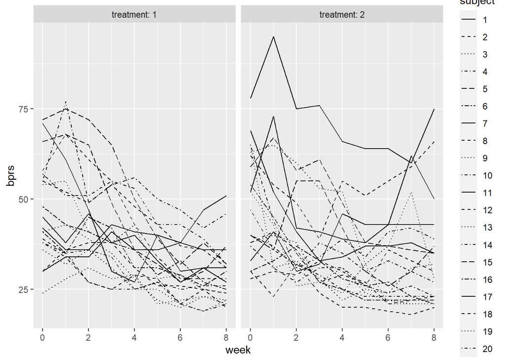

```r
#Load the library to R
library(ggplot2)

# Draw the plot
ggplot(BPRSL, aes(x = week, y = bprs, linetype = subject)) +
  geom_line() +
  scale_linetype_manual(values = rep(1:10, times=4)) +
  facet_grid(. ~ treatment, labeller = label_both) +
  theme(legend.position = "right") +
  scale_y_continuous(limits = c(min(BPRSL$bprs), max(BPRSL$bprs)))
```

Each subject (shown by lines) are each individual (men) who participated in the experiment so there were 20 men per treatment subjects thus 20 lines in each graphs.  
We can see how the subjects (per person) and bprs values changed (generally declined) during weeks for persons, for each treatmets.

```r
#let's write the wrangled data to files in drive
write.csv(BPRSL, "BPRSL.csv")
```

## *Part 2) Data analysis*

**Task 1**: Implement the analyses of Chapter 8 of MABS using the RATS data.  
As mentioned in the textbook of the course, the graphical Displays of Longitudinal Data is to:  
"• Show as much of the relevant raw data as possible rather than only data summaries  
• Highlight aggregate patterns of potential scientific interest  
• Identify both cross-sectional and longitudinal patterns  
• Try to make the identification of unusual individuals or unusual observations simple.

**Standardise the variable bprs** Standardising the values of a phenomenon can lead to a better and clearer tracking and viewing the data. We can do it by subtracting the relevant occasion mean from the original observation and then dividing by the corresponding visit standard deviation.

```r
BPRSL <- BPRSL %>%
  group_by(week) %>%
  mutate(stdbprs = (bprs - mean(bprs))/sd(bprs) ) %>%
  ungroup()

# Glimpse the data
glimpse(BPRSL)
```

```
## Rows: 360
## Columns: 6
## $ treatment <fct> 1, 1, 1, 1, 1, 1, 1, 1, 1, 1, 1, 1, 1, 1, 1, 1, 1, 1, 1, ...
## $ subject   <fct> 1, 2, 3, 4, 5, 6, 7, 8, 9, 10, 11, 12, 13, 14, 15, 16, 17...
## $ weeks     <chr> "week0", "week0", "week0", "week0", "week0", "week0", "we...
## $ bprs      <int> 42, 58, 54, 55, 72, 48, 71, 30, 41, 57, 30, 55, 36, 38, 6...
## $ week      <int> 0, 0, 0, 0, 0, 0, 0, 0, 0, 0, 0, 0, 0, 0, 0, 0, 0, 0, 0, ...
## $ stdbprs   <dbl> -0.4245908, 0.7076513, 0.4245908, 0.4953559, 1.6983632, 0...
```

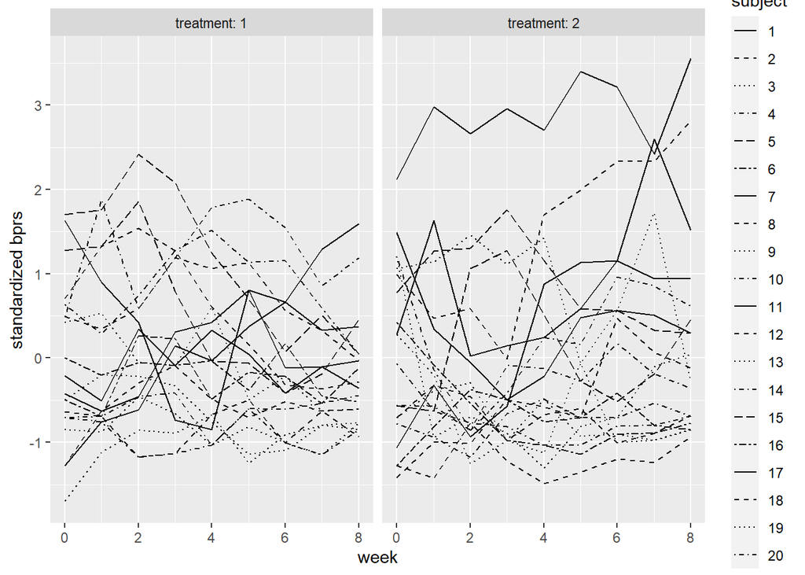

```r
# Plot again with the standardised bprs
ggplot(BPRSL, aes(x = week, y = stdbprs, linetype = subject)) +
  geom_line() +
  scale_linetype_manual(values = rep(1:10, times=4)) +
  facet_grid(. ~ treatment, labeller = label_both) +
  scale_y_continuous(name = "standardized bprs")
```

```r
# Number of weeks, baseline (week 0) included
n <- BPRSL$week %>% unique() %>% length()
```

So there were 9 weeks, i.e. the duration of treatment.

```r
# Summary data with mean and standard error of bprs by treatment and week
BPRSS <- BPRSL %>%
  group_by(treatment, week) %>%
  summarise( mean = mean(bprs), se = sd(bprs)/sqrt(n) ) %>%
  ungroup()
# Glimpse the data
glimpse(BPRSS)
```

```
## Rows: 18
## Columns: 4
## $ treatment <fct> 1, 1, 1, 1, 1, 1, 1, 1, 1, 2, 2, 2, 2, 2, 2, 2, 2, 2
## $ week      <int> 0, 1, 2, 3, 4, 5, 6, 7, 8, 0, 1, 2, 3, 4, 5, 6, 7, 8
## $ mean      <dbl> 47.00, 46.80, 43.55, 40.90, 36.60, 32.70, 29.70, 29.80, 2...
## $ se        <dbl> 4.534468, 5.173708, 4.003617, 3.744626, 3.259534, 2.59576...
```

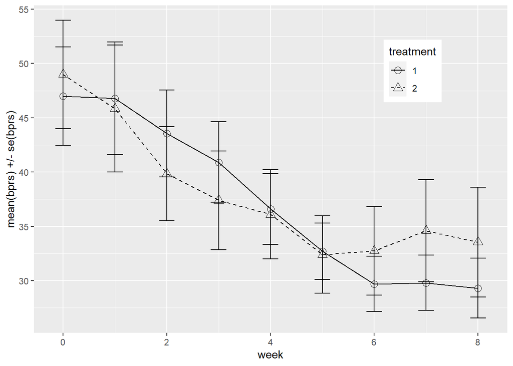

```r
# Plot the mean profiles
ggplot(BPRSS, aes(x = week, y = mean, linetype = treatment, shape = treatment)) +
  geom_line() +
  scale_linetype_manual(values = c(1,2)) +
  geom_point(size=3) +
  scale_shape_manual(values = c(1,2)) +
  geom_errorbar(aes(ymin = mean - se, ymax = mean + se, linetype="1"), width=0.3) +
  theme(legend.position = c(0.8,0.8)) +
  scale_y_continuous(name = "mean(bprs) +/- se(bprs)")
```

#———————– **Find and discard outliers** Create a summary data by treatment and subject with mean as the summary variable (ignoring baseline week 0).

```r
BPRSL8S <- BPRSL %>%
  filter(week > 0) %>%
  group_by(treatment, subject) %>%
  summarise( mean=mean(bprs) ) %>%
  ungroup()
# Glimpse the data
glimpse(BPRSL8S)
```

```
## Rows: 40
## Columns: 3
## $ treatment <fct> 1, 1, 1, 1, 1, 1, 1, 1, 1, 1, 1, 1, 1, 1, 1, 1, 1, 1, 1, ...
## $ subject   <fct> 1, 2, 3, 4, 5, 6, 7, 8, 9, 10, 11, 12, 13, 14, 15, 16, 17...
## $ mean      <dbl> 41.500, 43.125, 35.375, 52.625, 50.375, 34.000, 37.125, 3...
```

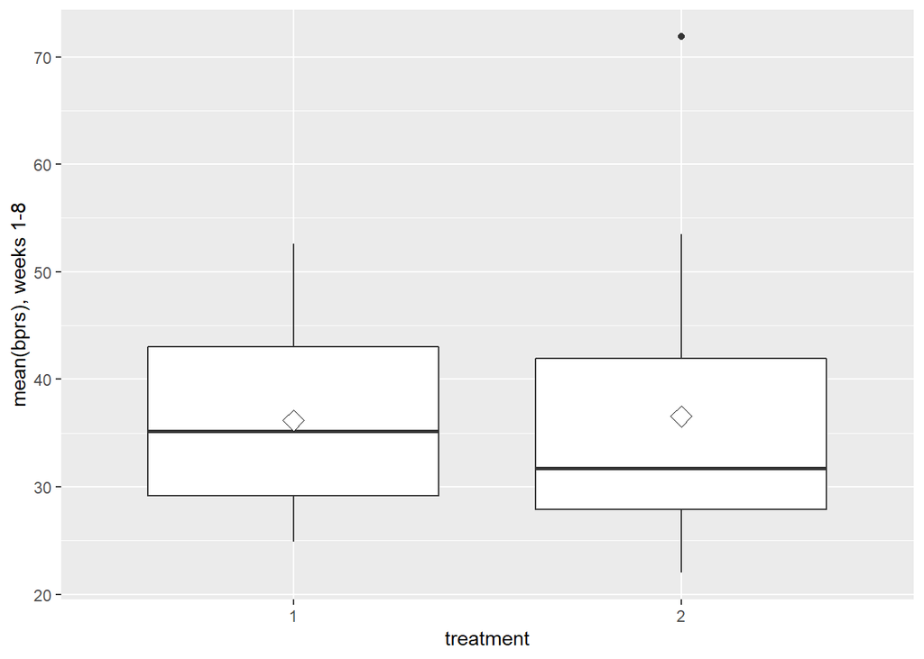

```r
# Draw a boxplot of the mean versus treatment
ggplot(BPRSL8S, aes(x = treatment, y = mean)) +
  geom_boxplot() +
  stat_summary(fun.y = "mean", geom = "point", shape=23, size=4, fill = "white") +
  scale_y_continuous(name = "mean(bprs), weeks 1-8")
```

```r
# Create a new data by filtering the outlier and adjust the ggplot code the draw the plot again with the new data
BPRSL8S1 <- BPRSL8S %>%
  filter(mean < 60)
```

Here, we used ‘filter’ function which subsets rows using column values, in this case mean < 60, so keeps any value below 60.

**A t-test to check group differences**  
Although the graph showed all indicated a lack of difference in the two treatment groups, we better check with statistical tests like t-test if the difference exist between treatments.  
we will use the data without outlier. So, lets proceed…

```r
# Perform a two-sample t-test
t.test(mean ~ treatment, data = BPRSL8S1, var.equal = TRUE)
```

```
##
##  Two Sample t-test
##
## data:  mean by treatment
## t = 0.52095, df = 37, p-value = 0.6055
## alternative hypothesis: true difference in means is not equal to 0
## 95 percent confidence interval:
##  -4.232480  7.162085
## sample estimates:
## mean in group 1 mean in group 2
##        36.16875        34.70395
```

**Linear regression and ANOVA analysis**  
Now, let’s add a baseline to our calculations, because as book says baseline measurements of the outcome variable in a longitudinal study are often correlated with the chosen summary measure and using such measures in the analysis can often lead to substantial gains in precision when used appropriately as a covariate in an analysis of covariance.

```r
# Add the baseline from the original data as a new variable to the summary data
BPRSL8S2 <- BPRSL8S %>%
  mutate(baseline = BPRS$week0)

# Fit the linear model with the mean as the response
fit <- lm(mean ~ baseline + treatment, data = BPRSL8S2)

# Compute the analysis of variance table for the fitted model with anova()
anova(fit)
```

```
## Analysis of Variance Table
##
## Response: mean
##           Df  Sum Sq Mean Sq F value    Pr(>F)
## baseline   1 1868.07 1868.07 30.1437 3.077e-06 ***
## treatment  1    3.45    3.45  0.0557    0.8148
## Residuals 37 2292.97   61.97
## ---
## Signif. codes:  0 '***' 0.001 '**' 0.01 '*' 0.05 '.' 0.1 ' ' 1
```

The ANOVA test shows that the baseline is statistically significant with BPRS values taken after treatment has begun, but treatments are not statistically significant (Pr = 0.8148 which is higher than 0.05 confidence interval) difference in BPRS values even after conditioning on the baseline value. Thus, same conclusion as t-test (explained above).

**Analyzing rats data**  
**´Now, let’s do the same for RATS data**

```r
# read the RATS data
RATS <- read.table("https://raw.githubusercontent.com/KimmoVehkalahti/MABS/master/Examples/data/rats.txt", header = TRUE, sep = '\t')
```

**Data description:** This dataset belong to a nutrition study carried out using three groups of rats. The groups were put on different diets, and each animal’s body weight (grams) was recorded repeatedly (approximately) weekly, except in week seven when two recordings were taken) over a 9-week period. The question of most interest is whether the growth profiles of the three groups differ.  
So, let’s study the question…

```r
library(GGally)
```

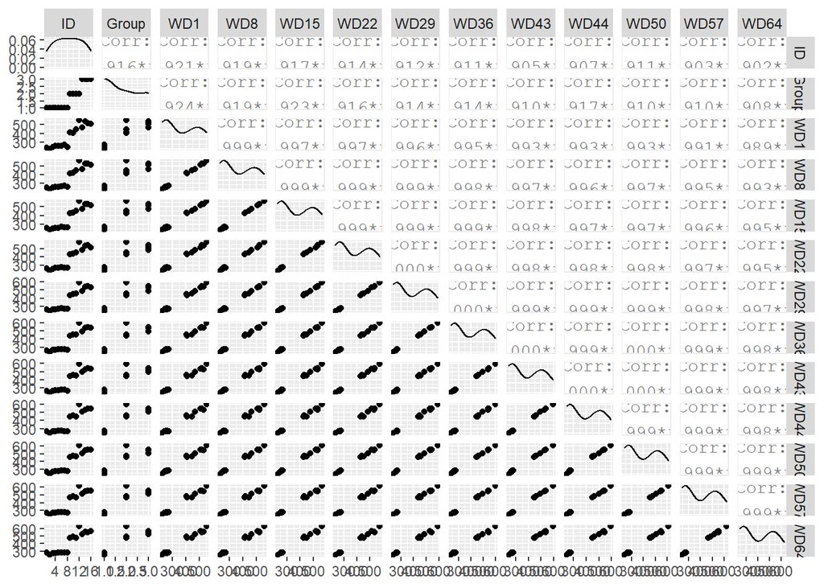

```r
ggpairs(RATS, lower = list(combo = wrap("facethist", bins = 20)))
```

We can see that the varables are all highly (above 0.9) correlated to each other, so we need to wonder about it. Stay tuned, we will tell in a bit.

```r
# Factor variables ID and Group
RATS$ID <- factor(RATS$ID)
RATS$Group <- factor(RATS$Group)

# Glimpse the data
glimpse(RATS)
```

```
## Rows: 16
## Columns: 13
## $ ID    <fct> 1, 2, 3, 4, 5, 6, 7, 8, 9, 10, 11, 12, 13, 14, 15, 16
## $ Group <fct> 1, 1, 1, 1, 1, 1, 1, 1, 2, 2, 2, 2, 3, 3, 3, 3
## $ WD1   <int> 240, 225, 245, 260, 255, 260, 275, 245, 410, 405, 445, 555, 4...
## $ WD8   <int> 250, 230, 250, 255, 260, 265, 275, 255, 415, 420, 445, 560, 4...
## $ WD15  <int> 255, 230, 250, 255, 255, 270, 260, 260, 425, 430, 450, 565, 4...
## $ WD22  <int> 260, 232, 255, 265, 270, 275, 270, 268, 428, 440, 452, 580, 4...
## $ WD29  <int> 262, 240, 262, 265, 270, 275, 273, 270, 438, 448, 455, 590, 4...
## $ WD36  <int> 258, 240, 265, 268, 273, 277, 274, 265, 443, 460, 455, 597, 4...
## $ WD43  <int> 266, 243, 267, 270, 274, 278, 276, 265, 442, 458, 451, 595, 4...
## $ WD44  <int> 266, 244, 267, 272, 273, 278, 271, 267, 446, 464, 450, 595, 5...
## $ WD50  <int> 265, 238, 264, 274, 276, 284, 282, 273, 456, 475, 462, 612, 5...
## $ WD57  <int> 272, 247, 268, 273, 278, 279, 281, 274, 468, 484, 466, 618, 5...
## $ WD64  <int> 278, 245, 269, 275, 280, 281, 284, 278, 478, 496, 472, 628, 5...
```

**Linear Mixed Effects Models:**

```r
# Convert data to long form
## Converting the long form is explained in above for BPRS data, so I don't repeat the explanation now
RATSL <- RATS %>%
  gather(key = WD, value = Weight, -ID, -Group) %>% ###Convert data to long form
  mutate(Time = as.integer(substr(WD,3,4))) ### Extract the week number

dim(RATSL)
```

```
## [1] 176   5
```

```r
dim(RATS)
```

```
## [1] 16 13
```

As you can see, we used Gather function to Gather columns into key-value pairs, so the three columns called Time and it contains now week numbers and rats value is the value of measurement. So, now we converted the data to long form.  
So now we made a new integer column of weeks number.

```r
# Glimpse the data
glimpse(RATSL)
```

```
## Rows: 176
## Columns: 5
## $ ID     <fct> 1, 2, 3, 4, 5, 6, 7, 8, 9, 10, 11, 12, 13, 14, 15, 16, 1, 2,...
## $ Group  <fct> 1, 1, 1, 1, 1, 1, 1, 1, 2, 2, 2, 2, 3, 3, 3, 3, 1, 1, 1, 1, ...
## $ WD     <chr> "WD1", "WD1", "WD1", "WD1", "WD1", "WD1", "WD1", "WD1", "WD1...
## $ Weight <int> 240, 225, 245, 260, 255, 260, 275, 245, 410, 405, 445, 555, ...
## $ Time   <int> 1, 1, 1, 1, 1, 1, 1, 1, 1, 1, 1, 1, 1, 1, 1, 1, 8, 8, 8, 8, ...
```

You can see that we have 176 rows and 5 columns.

```r
#------------------
"Plot first, ask questions later"
```

```
## [1] "Plot first, ask questions later"
```

```r
# Check the dimensions of the data
dim(RATSL)
```

```
## [1] 176   5
```

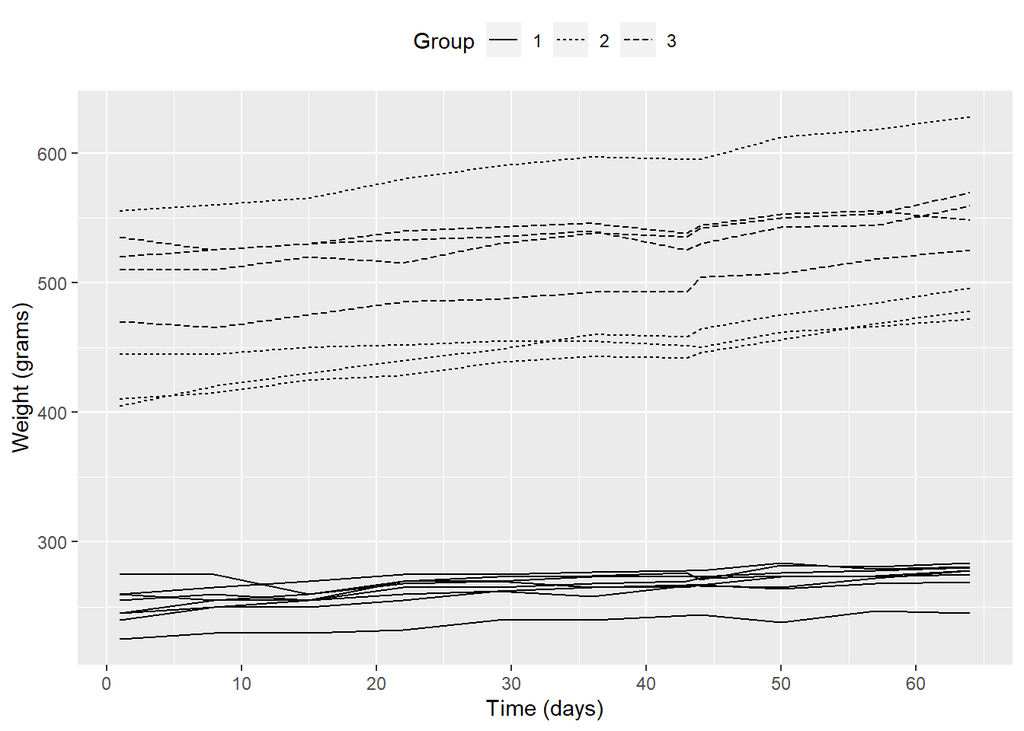

```r
# Let's draw a plot
ggplot(RATSL, aes(x = Time, y = Weight, group = ID)) +
  geom_line(aes(linetype = Group)) +
  scale_x_continuous(name = "Time (days)", breaks = seq(0, 60, 10)) +
  scale_y_continuous(name = "Weight (grams)") +
  theme(legend.position = "top")
```

As plot shows, the weights of rats generally increased over time of experiments. The weight of group 1 rats were distinguishable lower than group 2 and 3. the increase in weight of group 2 and 3 rats were seems to be sharper than group 1 rats.  
Additionally, it seems that the repeated measures are dependent of one another.

```r
#let's write the wrangled data to files in drive
write.csv("RATSL, RATSL.csv")
```

```
## "","x"
## "1","RATSL, RATSL.csv"
```

**Linear model**  
Let’s fit a multiple linear regression model with ignoring repeated-measures structure of the data, i.e. we hold on with the independence.

```r
# create a regression model RATS_reg
RATS_reg <- lm(Weight ~ Time + Group, data = RATSL)
```

We fitted a multiple linear regression model with weight as response and Time and Group as explanatory variables.

```r
# print out a summary of the model
summary(RATS_reg)
```

```
##
## Call:
## lm(formula = Weight ~ Time + Group, data = RATSL)
##
## Residuals:
##     Min      1Q  Median      3Q     Max
## -60.643 -24.017   0.697  10.837 125.459
##
## Coefficients:
##             Estimate Std. Error t value Pr(>|t|)
## (Intercept) 244.0689     5.7725  42.281  < 2e-16 ***
## Time          0.5857     0.1331   4.402 1.88e-05 ***
## Group2      220.9886     6.3402  34.855  < 2e-16 ***
## Group3      262.0795     6.3402  41.336  < 2e-16 ***
## ---
## Signif. codes:  0 '***' 0.001 '**' 0.01 '*' 0.05 '.' 0.1 ' ' 1
##
## Residual standard error: 34.34 on 172 degrees of freedom
## Multiple R-squared:  0.9283, Adjusted R-squared:  0.9271
## F-statistic: 742.6 on 3 and 172 DF,  p-value: < 2.2e-16
```

**Interpretation** Becuase the P-values of all variables (time, group 2 and 3) were very much lower than 0.05, thus they are definately different from each other. Thus, they are all highly significantly different.  
Also there is high variation in the intercepts of the regression fits of the individual rat growth profiles.  
**Notable**, because we ignored the probable within-subject dependences, the standard error of a within-subject covariate such as time being larger. Thus, now we should create Random Intercept Model to consider it.

**Random Intercept Model**

```r
# access library lme4
library(lme4)
# Create a random intercept model
RATS_ref <- lmer(Weight ~ Time + Group + (1 | ID), data = RATSL, REML = FALSE)
```

`Note the random-effects terms distinguished by vertical bars (|).`

```r
# Print the summary of the model
summary(RATS_ref)
```

```
## Linear mixed model fit by maximum likelihood  ['lmerMod']
## Formula: Weight ~ Time + Group + (1 | ID)
##    Data: RATSL
##
##      AIC      BIC   logLik deviance df.resid
##   1333.2   1352.2   -660.6   1321.2      170
##
## Scaled residuals:
##     Min      1Q  Median      3Q     Max
## -3.5386 -0.5581 -0.0494  0.5693  3.0990
##
## Random effects:
##  Groups   Name        Variance Std.Dev.
##  ID       (Intercept) 1085.92  32.953
##  Residual               66.44   8.151
## Number of obs: 176, groups:  ID, 16
##
## Fixed effects:
##              Estimate Std. Error t value
## (Intercept) 244.06890   11.73107   20.80
## Time          0.58568    0.03158   18.54
## Group2      220.98864   20.23577   10.92
## Group3      262.07955   20.23577   12.95
##
## Correlation of Fixed Effects:
##        (Intr) Time   Group2
## Time   -0.090
## Group2 -0.575  0.000
## Group3 -0.575  0.000  0.333
```

### **Extra coding 1: Extracting all the coefficients**

*Insprited from https://web.stanford.edu/class/psych252/section/Mixed_models_tutorial.html*

```r
d_bysubj = na.omit(RATSL) %>%
  group_by(Group) %>%
  summarise(mean_weight_of_Rats = mean(Weight))
```

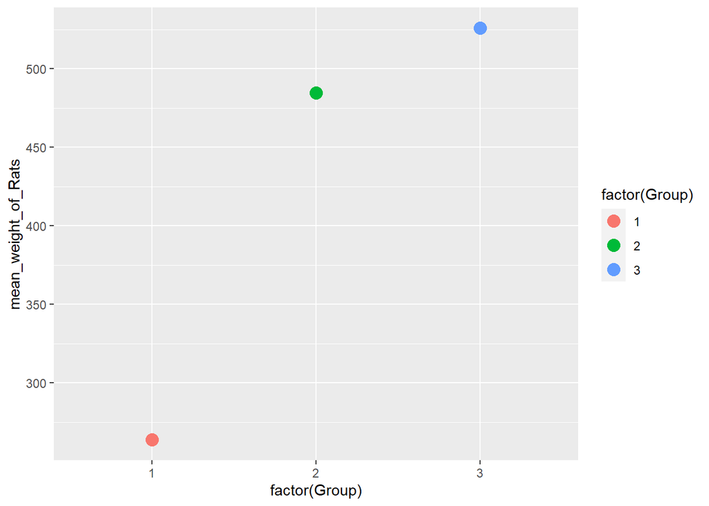

```r
ggplot(d_bysubj, aes(x=factor(Group), y=mean_weight_of_Rats)) +
  geom_point(size=4, aes(colour = factor(Group)))
```

We can see that mean weight of rats in group 1 is very lower than group 2 and 3 (maximum).

**Random Intercept and Random Slope Model**  
Now, let us proceed to fit the random intercept and random slope model to the rat growth data. Fitting a random intercept and random slope model allows the linear regression fits for each individual to differ in intercept but also in slope. This way it is possible to consider the individual differences in the rats’ growth profiles, but also the effect of time.

```r
# create a random intercept and random slope model
RATS_ref1 <- lmer(Weight ~ Time + Group + (Time | ID), data = RATSL, REML = FALSE)
# print a summary of the model
summary(RATS_ref1)
```

```
## Linear mixed model fit by maximum likelihood  ['lmerMod']
## Formula: Weight ~ Time + Group + (Time | ID)
##    Data: RATSL
##
##      AIC      BIC   logLik deviance df.resid
##   1194.2   1219.6   -589.1   1178.2      168
##
## Scaled residuals:
##     Min      1Q  Median      3Q     Max
## -3.2259 -0.4322  0.0555  0.5637  2.8825
##
## Random effects:
##  Groups   Name        Variance  Std.Dev. Corr
##  ID       (Intercept) 1139.2004 33.7520
##           Time           0.1122  0.3349  -0.22
##  Residual               19.7479  4.4439
## Number of obs: 176, groups:  ID, 16
##
## Fixed effects:
##              Estimate Std. Error t value
## (Intercept) 246.46821   11.80888  20.871
## Time          0.58568    0.08548   6.852
## Group2      214.55803   20.16986  10.638
## Group3      258.91288   20.16986  12.837
##
## Correlation of Fixed Effects:
##        (Intr) Time   Group2
## Time   -0.166
## Group2 -0.569  0.000
## Group3 -0.569  0.000  0.333
## optimizer (nloptwrap) convergence code: 0 (OK)
## Model failed to converge with max|grad| = 0.0028726 (tol = 0.002, component 1)
```

```r
# perform an ANOVA test on the two models
anova(RATS_ref1, RATS_ref)
```

```
## Data: RATSL
## Models:
## RATS_ref: Weight ~ Time + Group + (1 | ID)
## RATS_ref1: Weight ~ Time + Group + (Time | ID)
##           npar    AIC    BIC  logLik deviance  Chisq Df Pr(>Chisq)
## RATS_ref     6 1333.2 1352.2 -660.58   1321.2
## RATS_ref1    8 1194.2 1219.6 -589.11   1178.2 142.94  2  < 2.2e-16 ***
## ---
## Signif. codes:  0 '***' 0.001 '**' 0.01 '*' 0.05 '.' 0.1 ' ' 1
```

The ANOVA test of the two models show that the latter model ‘random intercept and random slope model’ is significant because P value is much less than 0.05. It’s significant in 99% significant interval.

**Random Intercept and Random Slope Model with interaction**  
Let’s test differnet variables for the random intercept and random slope model with interaction.

```r
# create a random intercept and random slope model
RATS_ref2 <- lmer(Weight ~ Time * Group + (Time | ID), data = RATSL, REML = FALSE)
# print a summary of the model
summary(RATS_ref2)
```

```
## Linear mixed model fit by maximum likelihood  ['lmerMod']
## Formula: Weight ~ Time * Group + (Time | ID)
##    Data: RATSL
##
##      AIC      BIC   logLik deviance df.resid
##   1185.9   1217.6   -582.9   1165.9      166
##
## Scaled residuals:
##     Min      1Q  Median      3Q     Max
## -3.2667 -0.4249  0.0726  0.6034  2.7511
##
## Random effects:
##  Groups   Name        Variance  Std.Dev. Corr
##  ID       (Intercept) 1.106e+03 33.2534
##           Time        4.925e-02  0.2219  -0.15
##  Residual             1.975e+01  4.4439
## Number of obs: 176, groups:  ID, 16
##
## Fixed effects:
##              Estimate Std. Error t value
## (Intercept) 251.65165   11.79473  21.336
## Time          0.35964    0.08215   4.378
## Group2      200.66549   20.42907   9.823
## Group3      252.07168   20.42907  12.339
## Time:Group2   0.60584    0.14229   4.258
## Time:Group3   0.29834    0.14229   2.097
##
## Correlation of Fixed Effects:
##             (Intr) Time   Group2 Group3 Tm:Gr2
## Time        -0.160
## Group2      -0.577  0.092
## Group3      -0.577  0.092  0.333
## Time:Group2  0.092 -0.577 -0.160 -0.053
## Time:Group3  0.092 -0.577 -0.053 -0.160  0.333
## optimizer (nloptwrap) convergence code: 0 (OK)
## Model failed to converge with max|grad| = 0.00504145 (tol = 0.002, component 1)
```

```r
# perform an ANOVA test on the two models
anova(RATS_ref2, RATS_ref1)
```

```
## Data: RATSL
## Models:
## RATS_ref1: Weight ~ Time + Group + (Time | ID)
## RATS_ref2: Weight ~ Time * Group + (Time | ID)
##           npar    AIC    BIC  logLik deviance  Chisq Df Pr(>Chisq)
## RATS_ref1    8 1194.2 1219.6 -589.11   1178.2
## RATS_ref2   10 1185.9 1217.6 -582.93   1165.9 12.361  2    0.00207 **
## ---
## Signif. codes:  0 '***' 0.001 '**' 0.01 '*' 0.05 '.' 0.1 ' ' 1
```

Now, we can see that the latter model in which we multiple time and groups is more significant (in 99% significance interval because P value is smaller than 0.01, compare to previous model where we did not make the multiplication.

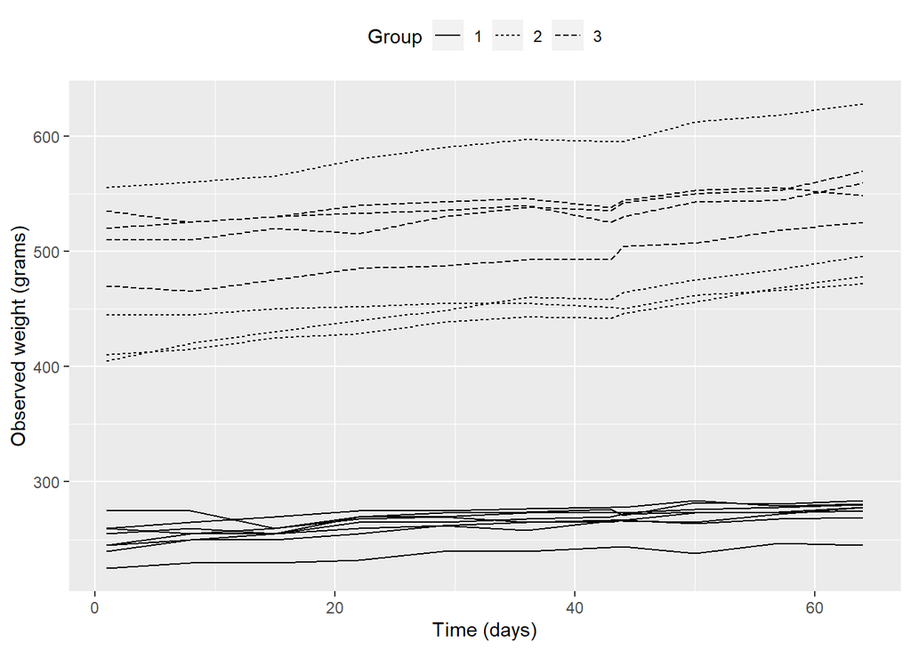

```r
# Create a vector of the fitted values
Fitted <- fitted(RATS_ref2)

# Create a new column fitted to RATSL
RATSL <- RATSL %>%
  mutate(Fitted)


# draw the plot of original RATSL
ggplot(RATSL, aes(x = Time, y = Weight, group = ID)) +
  geom_line(aes(linetype = Group)) +
  scale_x_continuous(name = "Time (days)", breaks = seq(0, 60, 20)) +
  scale_y_continuous(name = "Observed weight (grams)") +
  theme(legend.position = "top")
```

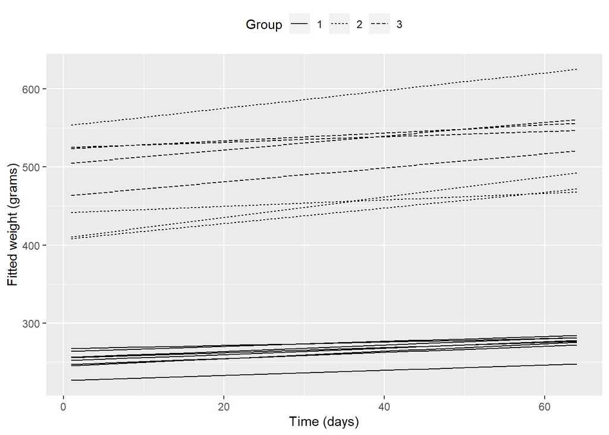

```r
# draw the plot of model fitted RATSL
ggplot(RATSL, aes(x = Time, y = Fitted, group = ID)) +
  geom_line(aes(linetype = Group)) +
  scale_x_continuous(name = "Time (days)", breaks = seq(0, 60, 20)) +
  scale_y_continuous(name = "Fitted weight (grams)") +
  theme(legend.position = "top")
```

We can see that the value of fitted weight, dervided from the last random intercept and random slope model look veey simlar to observations graph in earlier, thus it’s a successful and nice model. Good job!  
Thus, this graph shows that the interaction model fits well with the observed data (plotted earlier).

### **Extra coding 2: creating the standardized residual of predicted mean weights of each rat during the experiment**

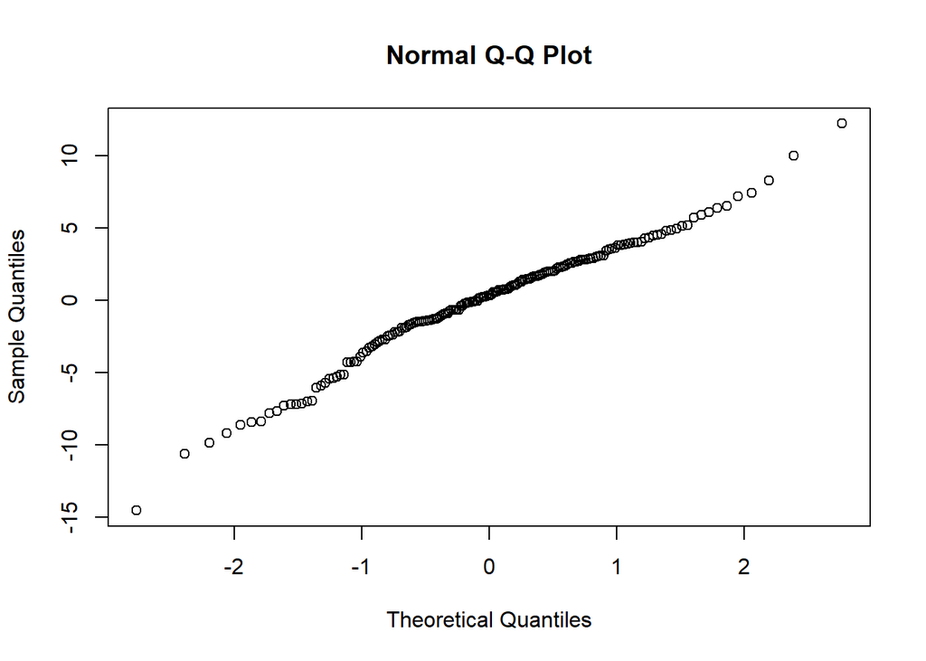

```r
# creating and plot the residuals  of model
resid <- residuals(RATS_ref2)
qqnorm(resid)
```

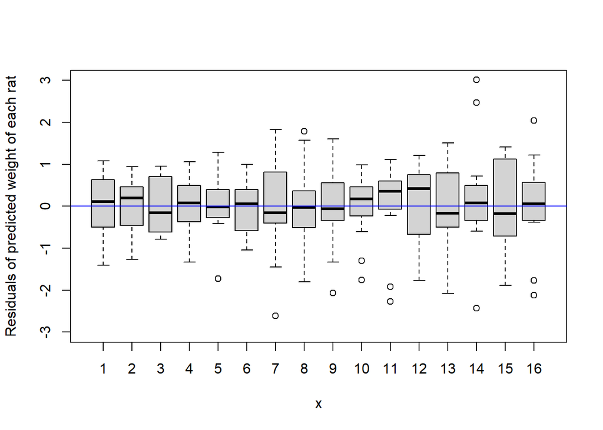

```r
resid.std <- resid/sd(resid)
plot(RATSL$ID, resid.std, ylim=c(-3, 3), ylab="Residuals of predicted weight of each rat")
abline(h=0, col= "blue")
```

It seems that the model predicted the weights well, because if the predicted mean weight, shown by middle line of each box, of each rat is closer to abline (horizontal line in middle of graph) the better. The blue line is to show the place of ideal case to have residuals close to 0.

### **Extra coding 3: Assess the model with RMSE and Bias**

Since we have original value and model fitted values for BPRS, we can calculate root mean square error (RMSE) the statistical metric that measures how far apart our fitted values are from our original values in a regression analysis, on average.  
*inspired from https://www.statology.org/how-to-calculate-rmse-in-r/*

```r
head(RATSL, 2) # to print columns with 2 row to make it easy in here to write the formula
```

```
##   ID Group  WD Weight Time   Fitted
## 1  1     1 WD1    240    1 245.6950
## 2  2     1 WD1    225    1 226.8826
```

```r
RMSE = sqrt(mean((RATSL$Weight - RATSL$Fitted)^2))
```

The smaller the RMSE, the better a model is able to fit the data.

Proportional RMSE

```r
RMSE_percent = 100*RMSE/mean(RATSL$Weight)
```

We can also calculate Mean squered error (MSE). It is another most common metrics used to measure the prediction accuracy of a model. It is also called bias.  
So, RMSE is 1.05%, which cofirms our model is predicting the weight of Rats very well. Good job!

```r
MSE = mean((RATSL$Weight - RATSL$Fitted)^2)
MSE
```

```
## [1] 16.31714
```

The lower the value for MSE, the more accurately a model is able to predict values.

```r
MSE_percent = 100*MSE/mean(RATSL$Weight)
MSE_percent
```

```
## [1] 4.243917
```

So, our model is 4.24% underestimating the actual weight of Rats weight"

### **Extra coding 4: plotting measured and fitted values together with abline**

Now, we can plot the model fitted mean weight (in X axis) vs original observed value (in Y axis).

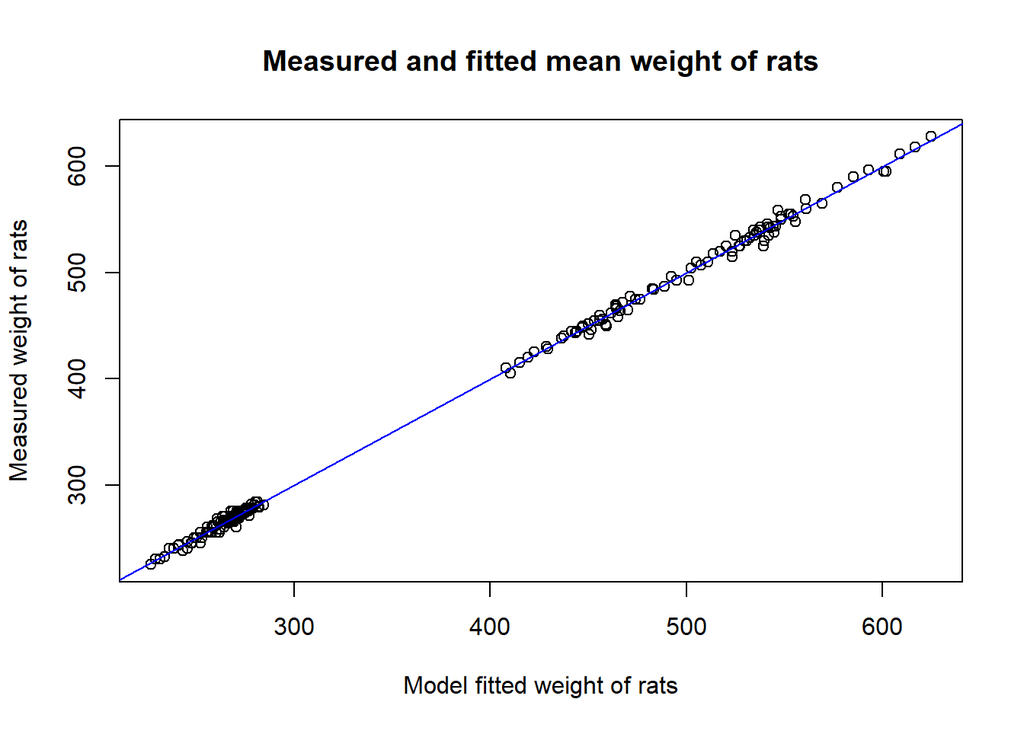

```r
plot(RATSL$Fitted, RATSL$Weight, main = "Measured and fitted mean weight of rats",
     xlab = "Model fitted weight of rats", ylab = "Measured weight of rats")
abline(a = 0, b= 1, col = "blue")
```

## **Now, Swapping the data**

Now, let’s **swap the data to use chapter 8 data for rats and chapter 9 for BPRS values**  
*Apply analysis from chapter 8 of textbook for the RATS dataset*

```r
RATSL <- RATSL %>%
  filter(Time > 1) %>%
  group_by(Group, ID) %>%
  summarise( mean=mean(Weight) ) %>%
  ungroup()
# Glimpse the data
glimpse(RATSL)
```

```
## Rows: 16
## Columns: 3
## $ Group <fct> 1, 1, 1, 1, 1, 1, 1, 1, 2, 2, 2, 2, 3, 3, 3, 3
## $ ID    <fct> 1, 2, 3, 4, 5, 6, 7, 8, 9, 10, 11, 12, 13, 14, 15, 16
## $ mean  <dbl> 263.2, 238.9, 261.7, 267.2, 270.9, 276.2, 274.6, 267.5, 443.9...
```

**NOTE:** Since I already have the plots and their interpretations (in upper section), I go straight Analysis part.  
Analysis of variance table for the fitted model, without baselines.

**Fit the linear model with the mean as the response on the swapped data**

```r
fit <- lm(mean ~ Group, data = RATSL)
summary(fit)
```

```
##
## Call:
## lm(formula = mean ~ Group, data = RATSL)
##
## Residuals:
##     Min      1Q  Median      3Q     Max
## -43.900 -27.169   2.325   9.069 106.200
##
## Coefficients:
##             Estimate Std. Error t value Pr(>|t|)
## (Intercept)   265.02      12.98  20.419 2.92e-11 ***
## Group2        222.77      22.48   9.909 2.00e-07 ***
## Group3        262.48      22.48  11.675 2.90e-08 ***
## ---
## Signif. codes:  0 '***' 0.001 '**' 0.01 '*' 0.05 '.' 0.1 ' ' 1
##
## Residual standard error: 36.71 on 13 degrees of freedom
## Multiple R-squared:  0.9316, Adjusted R-squared:  0.9211
## F-statistic: 88.52 on 2 and 13 DF,  p-value: 2.679e-08
```

As model summary shows, all variables of groups 2 and 3 as well as intercept of the model are significant (in confidence level of 99%).

**Compute the analysis of variance table for the fitted model with anova**

```r
anova(fit)
```

```
## Analysis of Variance Table
##
## Response: mean
##           Df Sum Sq Mean Sq F value    Pr(>F)
## Group      2 238620  119310  88.525 2.679e-08 ***
## Residuals 13  17521    1348
## ---
## Signif. codes:  0 '***' 0.001 '**' 0.01 '*' 0.05 '.' 0.1 ' ' 1
```

The ANOVA test shows that the ‘Group’ variable is statistically significant in confidence interval of 99%; thus, there is significant difference between Groups of rats weights.

**Apply analysis from chapter 9 of textbook for the Brief Psychiatric Rating Scale (BPRS) dataset**

**Regression model**

```r
reg_bprs <- lm(bprs ~ week + treatment, data = BPRSL)

summary(reg_bprs)
```

```
##
## Call:
## lm(formula = bprs ~ week + treatment, data = BPRSL)
##
## Residuals:
##     Min      1Q  Median      3Q     Max
## -22.454  -8.965  -3.196   7.002  50.244
##
## Coefficients:
##             Estimate Std. Error t value Pr(>|t|)
## (Intercept)  46.4539     1.3670  33.982   <2e-16 ***
## week         -2.2704     0.2524  -8.995   <2e-16 ***
## treatment2    0.5722     1.3034   0.439    0.661
## ---
## Signif. codes:  0 '***' 0.001 '**' 0.01 '*' 0.05 '.' 0.1 ' ' 1
##
## Residual standard error: 12.37 on 357 degrees of freedom
## Multiple R-squared:  0.1851, Adjusted R-squared:  0.1806
## F-statistic: 40.55 on 2 and 357 DF,  p-value: < 2.2e-16
```

The summary of linear model shows that the variable ‘weeks’ is significant (in confidence interval of 99% because Pr(>|t|) id <2e-16, however treatment2 is not significant because the value for it is 0.661.

**Random intercept model (model#1)**

```r
reg_bprs_Ran_intercept_1 <- lmer(bprs ~ week + treatment + (1 | subject ),
                                 data = BPRSL, REML = FALSE)
summary(reg_bprs_Ran_intercept_1)
```

```
## Linear mixed model fit by maximum likelihood  ['lmerMod']
## Formula: bprs ~ week + treatment + (1 | subject)
##    Data: BPRSL
##
##      AIC      BIC   logLik deviance df.resid
##   2748.7   2768.1  -1369.4   2738.7      355
##
## Scaled residuals:
##     Min      1Q  Median      3Q     Max
## -3.0481 -0.6749 -0.1361  0.4813  3.4855
##
## Random effects:
##  Groups   Name        Variance Std.Dev.
##  subject  (Intercept)  47.41    6.885
##  Residual             104.21   10.208
## Number of obs: 360, groups:  subject, 20
##
## Fixed effects:
##             Estimate Std. Error t value
## (Intercept)  46.4539     1.9090  24.334
## week         -2.2704     0.2084 -10.896
## treatment2    0.5722     1.0761   0.532
##
## Correlation of Fixed Effects:
##            (Intr) week
## week       -0.437
## treatment2 -0.282  0.000
```

```r
#Random intercept model (model#2)
reg_bprs_Ran_intercept_2 <- lmer(bprs ~ week + treatment + treatment*week + (week | subject),
                                 data = BPRSL, REML = FALSE)
summary(reg_bprs_Ran_intercept_2)
```

```
## Linear mixed model fit by maximum likelihood  ['lmerMod']
## Formula: bprs ~ week + treatment + treatment * week + (week | subject)
##    Data: BPRSL
##
##      AIC      BIC   logLik deviance df.resid
##   2744.3   2775.4  -1364.1   2728.3      352
##
## Scaled residuals:
##     Min      1Q  Median      3Q     Max
## -3.0512 -0.6271 -0.0768  0.5288  3.9260
##
## Random effects:
##  Groups   Name        Variance Std.Dev. Corr
##  subject  (Intercept) 64.9964  8.0620
##           week         0.9687  0.9842   -0.51
##  Residual             96.4707  9.8220
## Number of obs: 360, groups:  subject, 20
##
## Fixed effects:
##                 Estimate Std. Error t value
## (Intercept)      47.8856     2.2521  21.262
## week             -2.6283     0.3589  -7.323
## treatment2       -2.2911     1.9090  -1.200
## week:treatment2   0.7158     0.4010   1.785
##
## Correlation of Fixed Effects:
##             (Intr) week   trtmn2
## week        -0.650
## treatment2  -0.424  0.469
## wek:trtmnt2  0.356 -0.559 -0.840
```

```r
#Random intercept model (model#3)
reg_bprs_Ran_intercept_3 <- lmer(bprs ~ week + treatment + treatment*week + (treatment| subject),
                                 data = BPRSL, REML = FALSE)
summary(reg_bprs_Ran_intercept_3)
```

```
## Linear mixed model fit by maximum likelihood  ['lmerMod']
## Formula: bprs ~ week + treatment + treatment * week + (treatment | subject)
##    Data: BPRSL
##
##      AIC      BIC   logLik deviance df.resid
##   2581.0   2612.1  -1282.5   2565.0      352
##
## Scaled residuals:
##     Min      1Q  Median      3Q     Max
## -2.2782 -0.6037 -0.0797  0.4437  3.3942
##
## Random effects:
##  Groups   Name        Variance Std.Dev. Corr
##  subject  (Intercept)  64.53    8.033
##           treatment2  189.04   13.749   -0.56
##  Residual              53.27    7.298
## Number of obs: 360, groups:  subject, 20
##
## Fixed effects:
##                 Estimate Std. Error t value
## (Intercept)      47.8856     2.0573  23.275
## week             -2.6283     0.2107 -12.475
## treatment2       -2.2911     3.3859  -0.677
## week:treatment2   0.7158     0.2980   2.402
##
## Correlation of Fixed Effects:
##             (Intr) week   trtmn2
## week        -0.410
## treatment2  -0.586  0.249
## wek:trtmnt2  0.290 -0.707 -0.352
```

**Lets check ANOVA test on the models 1 and 2**

```r
anova(reg_bprs_Ran_intercept_1, reg_bprs_Ran_intercept_2)
```

```
## Data: BPRSL
## Models:
## reg_bprs_Ran_intercept_1: bprs ~ week + treatment + (1 | subject)
## reg_bprs_Ran_intercept_2: bprs ~ week + treatment + treatment * week + (week | subject)
##                          npar    AIC    BIC  logLik deviance  Chisq Df
## reg_bprs_Ran_intercept_1    5 2748.7 2768.1 -1369.4   2738.7
## reg_bprs_Ran_intercept_2    8 2744.3 2775.4 -1364.1   2728.3 10.443  3
##                          Pr(>Chisq)
## reg_bprs_Ran_intercept_1
## reg_bprs_Ran_intercept_2    0.01515 *
## ---
## Signif. codes:  0 '***' 0.001 '**' 0.01 '*' 0.05 '.' 0.1 ' ' 1
```

**Lets check ANOVA test on the models 1 and 3**

```r
anova(reg_bprs_Ran_intercept_1, reg_bprs_Ran_intercept_3)
```

```
## Data: BPRSL
## Models:
## reg_bprs_Ran_intercept_1: bprs ~ week + treatment + (1 | subject)
## reg_bprs_Ran_intercept_3: bprs ~ week + treatment + treatment * week + (treatment | subject)
##                          npar    AIC    BIC  logLik deviance  Chisq Df
## reg_bprs_Ran_intercept_1    5 2748.7 2768.1 -1369.4   2738.7
## reg_bprs_Ran_intercept_3    8 2581.0 2612.1 -1282.5   2565.0 173.69  3
##                          Pr(>Chisq)
## reg_bprs_Ran_intercept_1
## reg_bprs_Ran_intercept_3  < 2.2e-16 ***
## ---
## Signif. codes:  0 '***' 0.001 '**' 0.01 '*' 0.05 '.' 0.1 ' ' 1
```

**Interpretation** According to the value of Pr(>Chisq), the model 1 and model 3 pairs performed more significantly and better than model 1 and 2 pairs, because the first pair (model 1&3) gave smaller Pr(>Chisq) value which is significant in confidence interval of 99% (because the value is well below 0.01.  
Moreover, the AIC value of model was smaller (which reflects the betterness of the model.  
BIC is another statistical metric that we can use for assessing the models, the smaller the better. It penalizes model complexity (variables) more than AIC. Thus, the BIC value for model 3 was smallest.

Now we can plot the model fitted values with original BPRS values and calculate RMSE and Bias of the values.  
Since we have original value and model fitted values for BPRS, we can calculate root mean square error (RMSE) the statistical metric that measures how far apart our fitted values are from our original values in a regression analysis, on average.  
*inspired from https://www.statology.org/how-to-calculate-rmse-in-r/*

```r
RMSE = sqrt(mean((RATSL$Weight - RATSL$Fitted)^2))
# Create a vector of the fitted values
Fitted <- fitted(reg_bprs_Ran_intercept_3)

RMSE = sqrt(mean((BPRSL$bprs - Fitted)^2))
```

The smaller the RMSE, the better a model is able to fit the data.

```r
RMSE_percent = 100*RMSE/mean(BPRSL$bprs)
RMSE_percent
```

```
## [1] 18.34506
```

We can also calculate Mean squared error (MSE). It is another most common metrics used to measure the prediction accuracy of a model. It is also called bias.  
So, RMSE is 18.34%, which confirms our model is predicting the BPRS values rather good. Good job!

```r
MSE = mean((BPRSL$bprs - Fitted)^2)
MSE
```

```
## [1] 47.72661
```

The lower the value for MSE, the more accurately a model is able to predict values.

```r
MSE_percent = 100*MSE/mean(BPRSL$bprs)
MSE_percent
```

```
## [1] 126.7358
```

So, our model is 126% underestimating the actual BPRS value, which is very high.

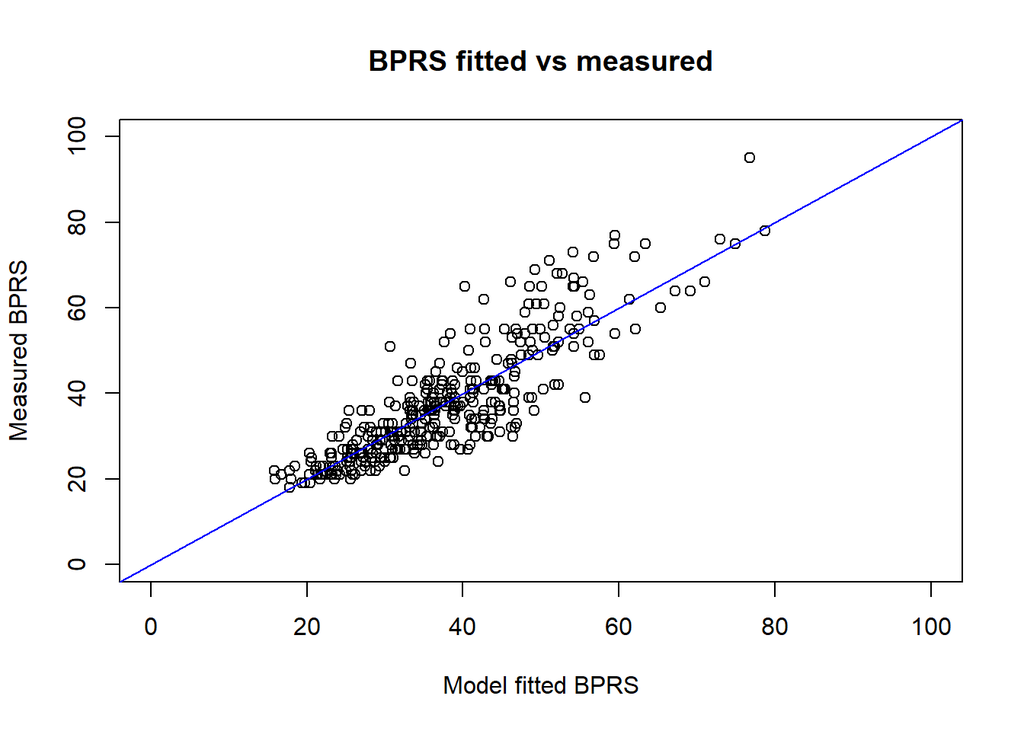

```r
plot(Fitted, BPRSL$bprs, main = "BPRS fitted vs measured",
     xlab = "Model fitted BPRS", ylab = "Measured BPRS",
     xlim = c(0,100), ylim=c(0,100))
abline(a = 0, b= 1, col = "blue", )
```

**Interpretation:** The blue line in graph shows the 1:1 diagonal line, for example if x = 500, y = 500, which will be in fact an ideal case.  
So, that line can help us easily compare our model fitted BPRS values vs original value, because if the measured value of BPRS is for example 40, then ideally the fitted BPRS value should ideally be 40 too. As graph shows, the predicted weights were closed to original values, however, the larger BPRS value were under-estimated. This underestimation was also confirmed by the MSE of 47.72, which is rather large(126%). However, the relative RMSE was 18.34%, which is rather good!

**Final notes** Independence was a most important assumption in the mixed models that we used here to resolve the non-independencies in our data. Otherwise, linear regression models could also do.

**Thanks for your reading my page. Please feel free to comment or ask question, and to contact me. :)**